# Predicting Bike Rentals

Joel Casillas, Ravinder Singh, and Ryan LeBon

May 11, 2018

# Introduction

This dataset contains the hourly and daily count of rental bikes between the year 2011 and 2012 in Capital bikeshare system with the corresponding weather and seasonal information. This dataset was obtained from [UC Irvines](https://archive.ics.uci.edu/ml/datasets/bike+sharing+dataset) machine learning repository. The data set contains integers and numerical values, so the task performed on this data set had to be regression. The data set contains 731 rows, and 16 columns total.

[Capital Bikeshare](https://www.capitalbikeshare.com) is metro DC’s bikeshare service, with 4,300 bikes and 500 stations across 5 jurisdictions: Washington, DC.; Arlington, VA; Alexandria, VA; Montgomery, MD and Fairfax County, VA. Designed for quick trips with convenience in mind, it’s a fun and affordable way to get around.

Hypothesis: Our goal for this project is to predict the best features that lead to the most bicycle rentals.

# Libraries Used

```r
set.seed(123)
library(rpart)
library(corrplot)
library(e1071)
library(rpart.plot)
library(cluster)
library(fpc)
source("lin-reg-util.R")
source("class-util.R")
```

# Data Cleaning & Pre-Processing

```r
dat=read.csv("https://raw.githubusercontent.com/Ryanbbq/datascience_final/master/day.csv")
hour=read.csv("https://raw.githubusercontent.com/Ryanbbq/datascience_final/master/hour.csv")
```

```r
sum(is.na(dat))
```

```
## [1] 0
```

```r
str(dat)
```

```
## 'data.frame':    731 obs. of  16 variables:
##  $ instant   : int  1 2 3 4 5 6 7 8 9 10 ...
##  $ dteday    : Factor w/ 731 levels "2011-01-01","2011-01-02",..: 1 2 3 4 5 6 7 8 9 10 ...
##  $ season    : int  1 1 1 1 1 1 1 1 1 1 ...
##  $ yr        : int  0 0 0 0 0 0 0 0 0 0 ...
##  $ mnth      : int  1 1 1 1 1 1 1 1 1 1 ...
##  $ holiday   : int  0 0 0 0 0 0 0 0 0 0 ...
##  $ weekday   : int  6 0 1 2 3 4 5 6 0 1 ...
##  $ workingday: int  0 0 1 1 1 1 1 0 0 1 ...
##  $ weathersit: int  2 2 1 1 1 1 2 2 1 1 ...
##  $ temp      : num  0.344 0.363 0.196 0.2 0.227 ...
##  $ atemp     : num  0.364 0.354 0.189 0.212 0.229 ...
##  $ hum       : num  0.806 0.696 0.437 0.59 0.437 ...
##  $ windspeed : num  0.16 0.249 0.248 0.16 0.187 ...
##  $ casual    : int  331 131 120 108 82 88 148 68 54 41 ...
##  $ registered: int  654 670 1229 1454 1518 1518 1362 891 768 1280 ...
##  $ cnt       : int  985 801 1349 1562 1600 1606 1510 959 822 1321 ...
```

# Data Exploration

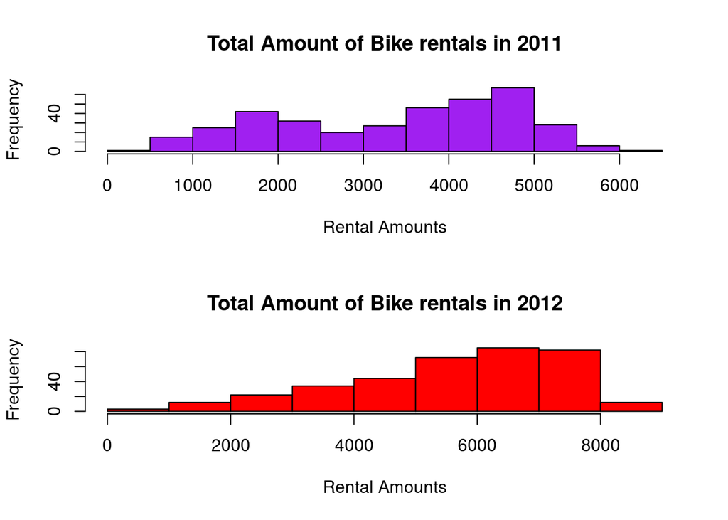

```r
par(mfrow=c(2,1))
Year2011 = dat[dat$yr==0,]
hist(Year2011$cnt,col = "purple",main = "Total Amount of Bike rentals in 2011",xlab = "Rental Amounts")
Year2012 = dat[dat$yr==1,]
hist(Year2012$cnt,col = "red",main = "Total Amount of Bike rentals in 2012",xlab = "Rental Amounts")
```

We wanted to get an idea of how bike rentals compared between years 2011 and 2012. 2012 was much better in all aspects as seen by the plot above.

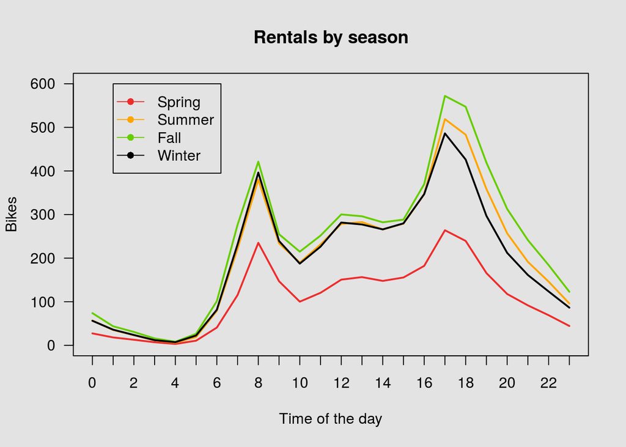

```r
season_1 = hour[hour$season ==1,]
season_2 = hour[hour$season ==2,]
season_3 = hour[hour$season ==3,]
season_4 = hour[hour$season ==4,]
x1 = aggregate(cnt~hr , data = season_1 , mean)
x2 = aggregate(cnt~hr , data = season_2 , mean)
x3 = aggregate(cnt~hr , data = season_3 , mean)
x4 = aggregate(cnt~hr , data = season_4 , mean)
par(bg = 'gray89')
plot(x1 , type = "l" , col = "firebrick2" , ylim =c(0 , 600) , xlim = c(0,23), lwd = 2 , main = "Rentals by season", las=1 , xaxt = "n" , ylab = "Bikes" , xlab = "Time of the day")
axis(1, at = seq(0, 24, by = 1), las=1)
lines(x2 , type = "l" , col ="orange" , lwd =2)
lines(x3 , type = "l" , col ="chartreuse3" ,lwd =2)
lines(x4 , type = "l" , col ="black" ,lwd =2)
legend(1 ,600 ,c('Spring' , 'Summer' , 'Fall', 'Winter') , col = c("firebrick2","orange" , "chartreuse3" , "black"),lty= 1 ,pch = 16)
```

We have four seasons in numerical values such as, spring as 1 , summer as 2 , fall as 3 and winter as 4. We plotted the total rental sales for each season in this plot. We can clearly see that fall and summer has the highest sales as we expected.

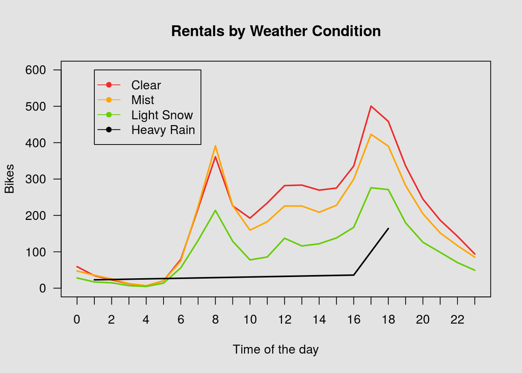

```r
weather_1 = hour[hour$weathersit ==1,]
weather_2 = hour[hour$weathersit ==2,]
weather_3 = hour[hour$weathersit ==3,]
weather_4 = hour[hour$weathersit ==4,]
y1 = aggregate(cnt~hr , data = weather_1 , mean)
y2 = aggregate(cnt~hr , data = weather_2 , mean)
y3 = aggregate(cnt~hr , data = weather_3 , mean)
y4 = aggregate(cnt~hr , data = weather_4 , mean)
par(bg = 'gray89')
plot(y1 , type = "l" , col = "firebrick2" , ylim =c(0 , 600) , xlim = c(0,23), lwd = 2 , main = "Rentals by Weather Condition", las=1 , xaxt = "n" , ylab = "Bikes" , xlab = "Time of the day")
axis(1, at = seq(0, 24, by = 1), las=1)
lines(y2 , type = "l" , col ="orange" , lwd =2)
lines(y3 , type = "l" , col ="chartreuse3" ,lwd =2)
lines(y4 , type = "l" , col ="black" ,lwd =2)
legend(1 ,600 ,c('Clear' , 'Mist' , 'Light Snow', 'Heavy Rain') , col = c("firebrick2","orange" , "chartreuse3" , "black"),lty= 1 ,pch = 16)
```

We have each day’s condition as clear, mist, little snow or heavy rain. Also, we have each day’s condition as numeric values from 1 to 4. We were expecting to see most of the rental sales on clear days. As we expected, most of the rental sales were on a clear day.

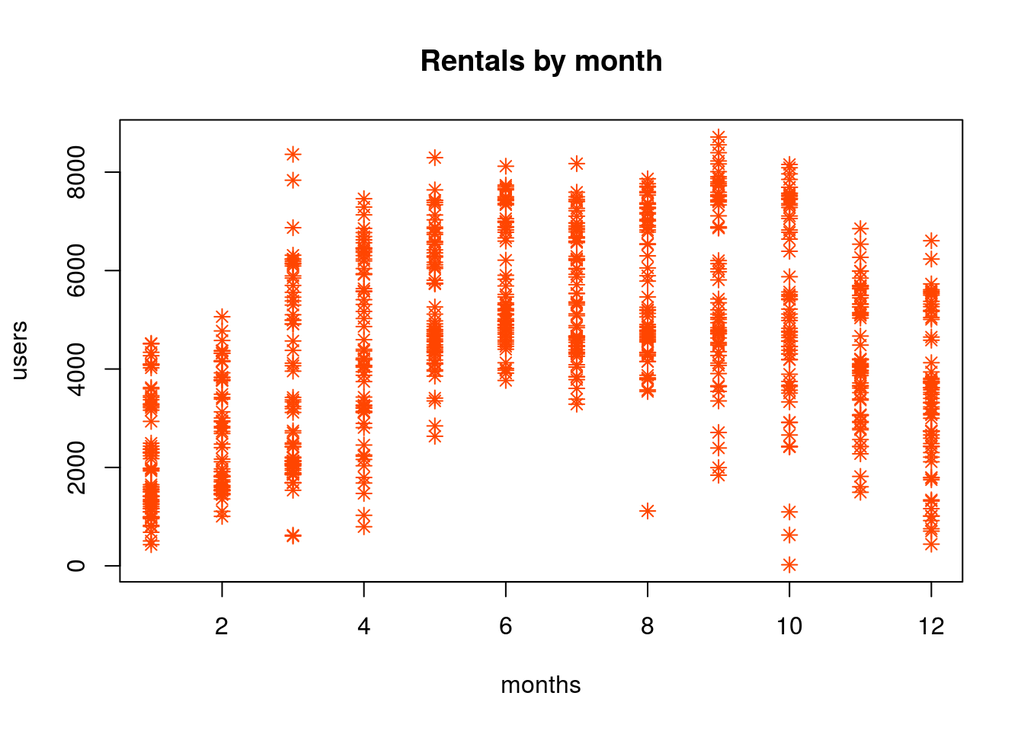

```r
plot(dat$cnt~dat$mnth, pch=8, ylab="users", xlab="months",col="orangered",main="Rentals by month")
```

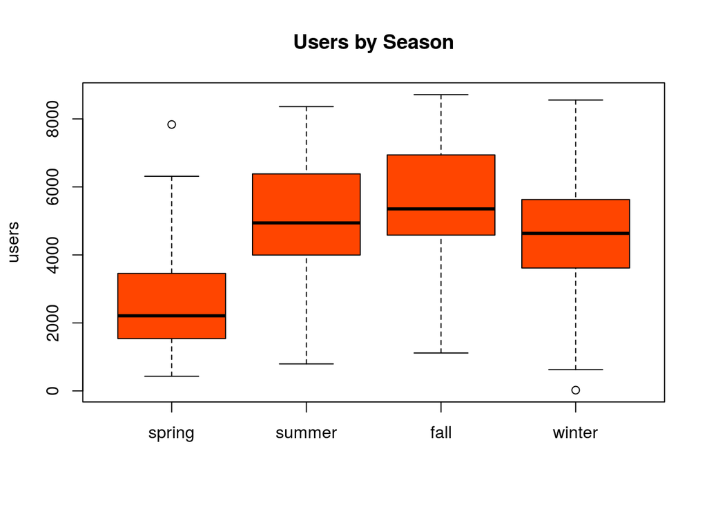

```r
boxplot(dat$cnt~dat$season,names=c("spring","summer","fall","winter"),ylab="users",col="orangered",main="Users by Season")
```

This is a boxplot of bikes that were being rented based on the season. We expected the most bikes to be rented during the summer but realized that the most bikes being rented was in the fall.

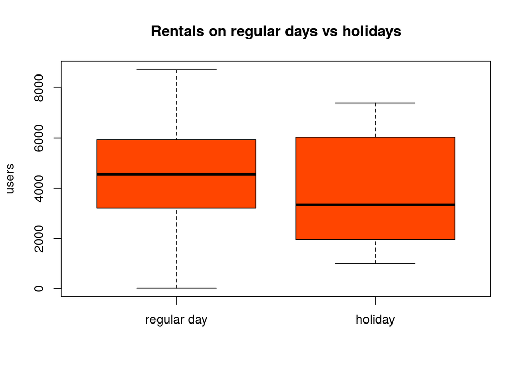

```r
boxplot(dat$cnt~dat$holiday, names=c("regular day","holiday"), ylab="users",col="orangered",main="Rentals on regular days vs holidays")
```

This is a boxplot of bikes that were rented on holidays and bikes that were rented on regular days.There were more users on regular days, but there was still a signficant amount of users on holidays.

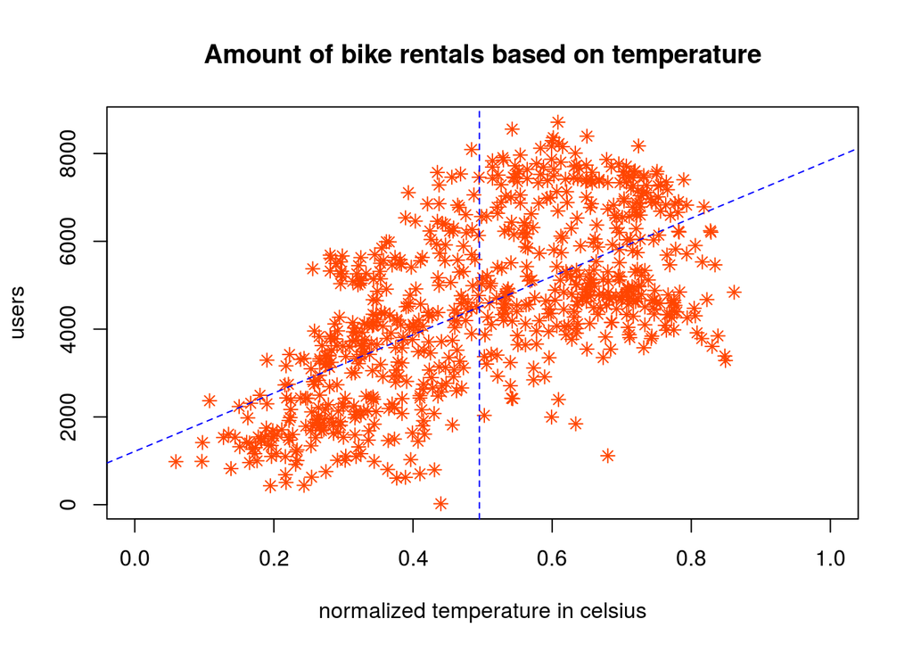

```r
plot(cnt ~ temp,data=dat,col="orangered",main="Amount of bike rentals based on temperature",ylab="users",xlab="normalized temperature in celsius",pch=8,xlim=c(0,1))
biketemp <- lm(cnt~temp,data=dat)
abline(biketemp,col="blue",lty="dashed")
mx  = mean(dat$temp)
abline(v = mx, col = "blue",lty="dashed")
```

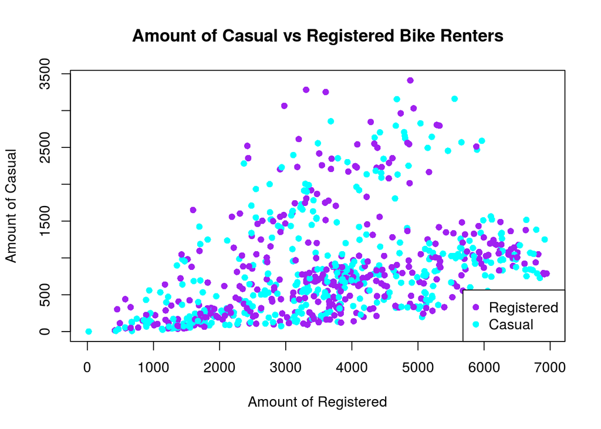

```r
plot(x=dat$registered,y=dat$casual,xlab = "Amount of Registered",ylab = "Amount of Casual",col=c("purple","cyan"),pch=16,main = "Amount of Casual vs Registered Bike Renters")
legend("bottomright", 95, legend=c("Registered", "Casual"),col=c("purple", "cyan"),pch = 16)
```

# Correlation Analysis

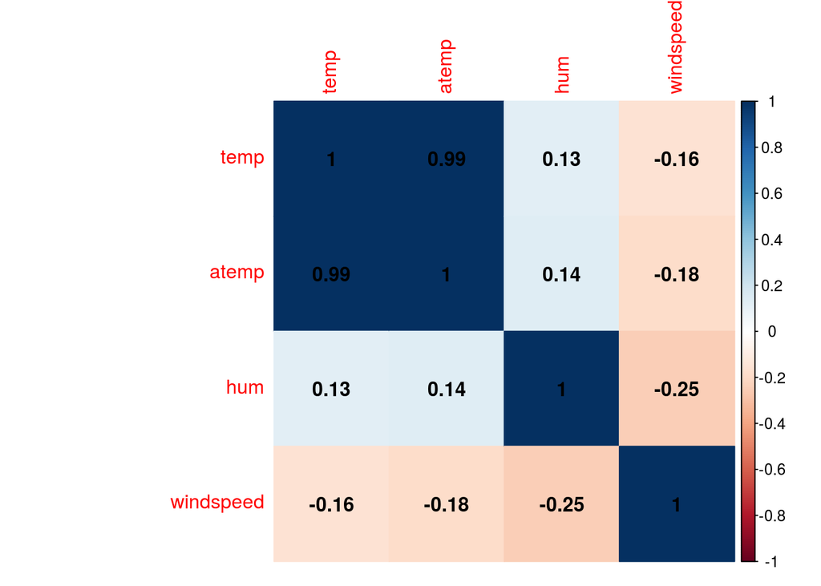

```r
bike_corr <- dat[,10:13]
train_cor <- cor(bike_corr)
corrplot(train_cor, method = 'color', addCoef.col="black")
```

# Cluster Analysis

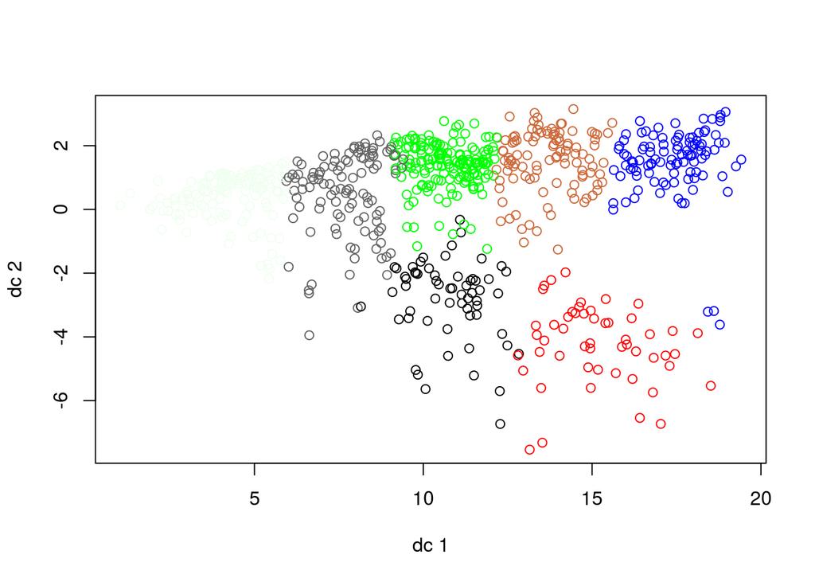

```r
cluster_dat <- dat
cluster_dat$dteday <- NULL
cluster_dat$instant <- NULL
cluster_dat$yr <- NULL
num_clust <- 7
bikes.myclust <- kmeans(cluster_dat,num_clust,algorithm="Lloyd",iter.max=100)
#str(bikes.myclust)
plotcluster(cluster_dat,bikes.myclust$cluster,pch=1,method="dc")
```

This cluster analysis plot distinguishes given classes. First k-means clustering was performed on the cluster data set using Lloyd’s algorithm, it is an algorithm named after Stuart P. Lloyd for finding evenly spaced sets of points in subsets of Euclidean spaces and partitions of these subsets into well-shaped and uniformly sized convex cells. We used 7 clusters for this example. We then used the plotcluster() function from the library ‘fpc’ to plot the cluster. The x and y axis dc1 and dc2 represent discriminant coordinates which are referred to as ‘canonical variates’. A canonical variate is a new variable (variate) formed by making a linear combination of two or more variates (variables) from a data set. A linear combination of variables is the same as a weighted sum of variables.

```r
good_or_bad <- bikes.myclust$totss / bikes.myclust$betweenss

paste0("If the bss/tss is close to a score of 1, then kmeans performed well...Score:(",round(good_or_bad,3),")")
```

[output not shown]

# Dendogram Analysis

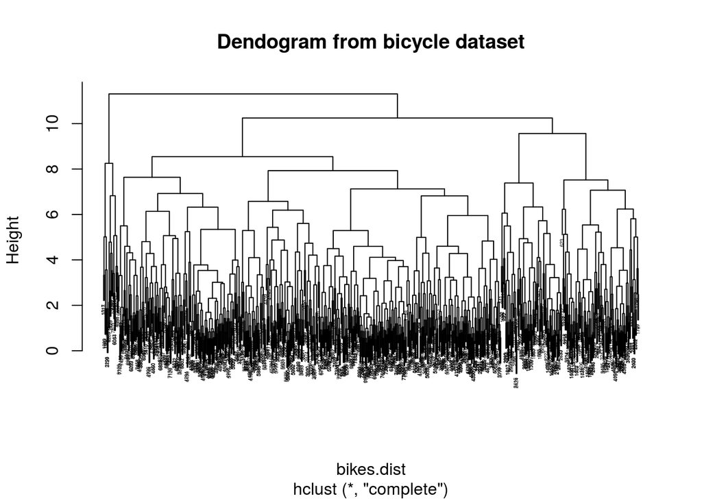

```r
library(ape)
dendo_dat <- dat
bikes.use = dendo_dat[,-c(1,2)]
bikes.use = scale(bikes.use)
bikes.dist = dist(bikes.use)
bikes.hclust = hclust(bikes.dist)
plot(bikes.hclust,labels=dendo_dat$cnt,main='Dendogram from bicycle dataset',cex=0.3)
```

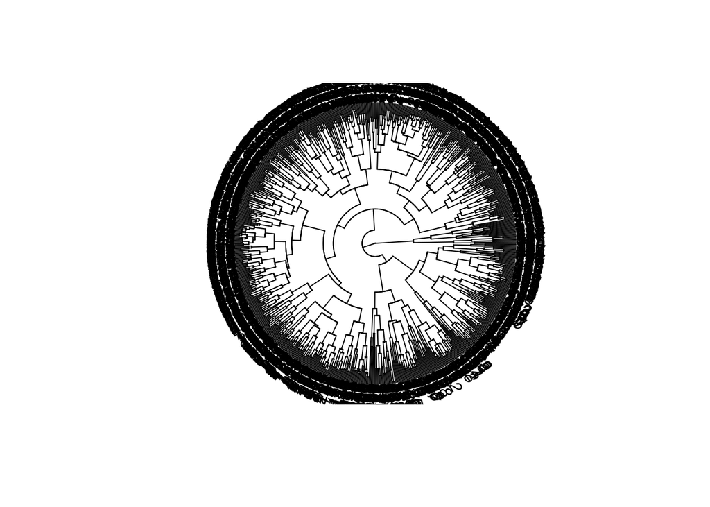

```r
plot(as.phylo(bikes.hclust), type = "fan")
```

This is a dendogram from the bicycle dataset. A dendograms is a tree diagram, that shows taxonomic relationships. However the dendogram had so many features that it was hard to compute exact values.

```r
dat = dat[,-1]
dat = dat[,-14]
dat = dat[,-13]
dat = dat[,-1]
dsets = split_data(dat, c(3,1))
tr_dat = dsets[[1]]
te_dat = dsets[[2]]
```

# Linear Regression Model

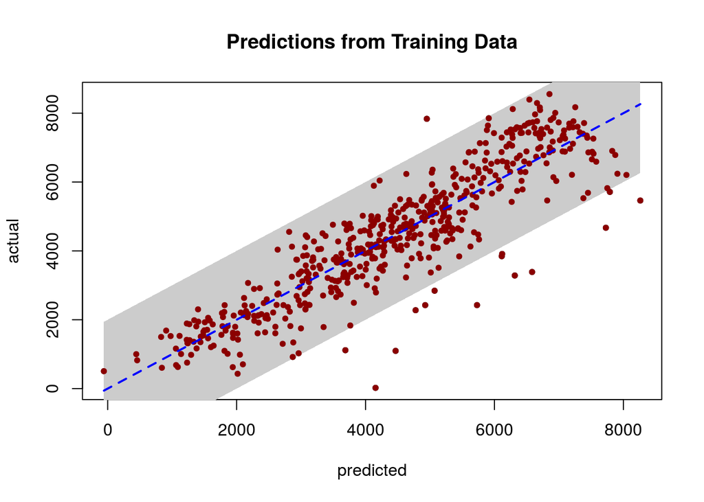

```r
fit = lm(cnt ~ ., data=tr_dat)
predicted = predict(fit, tr_dat)
actual= tr_dat$cnt
plot_predict_actual(predicted,actual,2000,title = "Predictions from Training Data")
```

This model is fitted using the best features to predict rentals of bikes in a day for the next year. This shows us that the model did pretty well on the training data, but that’s expected, the real test is running it on test data.

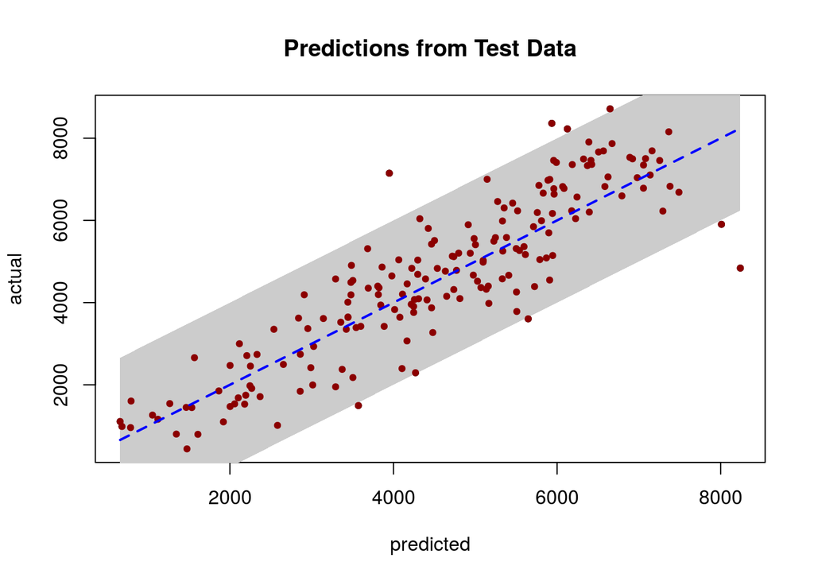

```r
predicted3 = predict(fit, te_dat)
actual3= te_dat$cnt
plot_predict_actual(predicted3,actual3,2000,title = "Predictions from Test Data")
```

Here we ran our fitted model on our test data and as you can see, it did a decent job of predicting bike rentals in a day. There is alot of residual on some parts but for the most part, the dots are close to the fitted line.

```r
predicted = predict(fit, te_dat)
errors = te_dat$cnt - predicted
rmse = sqrt(mean(errors^2))
paste0("The RMSE is ",round(rmse))
```

```
## [1] "The RMSE is 920"
```

# Diagnosing the fitted model

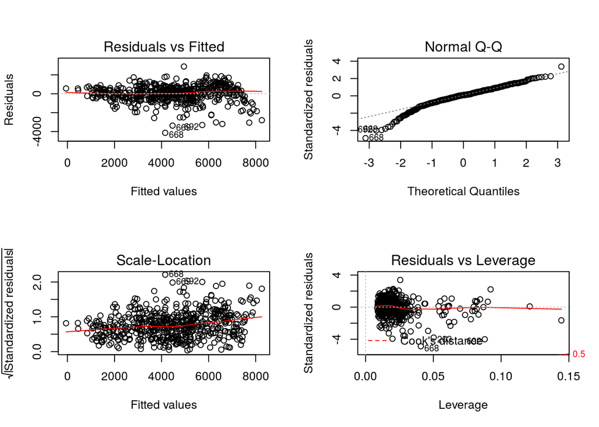

```r
par(mfrow=c(2,2))
plot(fit)
```

### Residuals vs. Fitted Plot

There is a clear indication that their is some linearity, but throughout the line, the variance is high. The variance increases on the fitted line towards the end.

### Scale-location Plot

We see a small increasing trend in residual variance towards the middle of the plot that runs through the end. This is indicated by the upward slope of the red line, which we can interpret as the standard deviation of the residuals at the given level of fitted value.

### Residuals vs Leverage Plot

There seems to be many outliers in this plot, because the trend for this is almost non-existent to the red line. You see no correlation at all.

# Decision Trees Regression Model

```r
model2 = rpart(cnt~ holiday + temp + atemp + workingday + windspeed, data = tr_dat)
prp(model2, extra= 1, varlen=-10,
main="regression tree  on total bikes a day ",
box.col="tan")
```

[figure not shown]

```r
predicted = predict(model2, te_dat)
actual =  te_dat$cnt
errors = te_dat$cnt - predicted
rmse = sqrt(mean(errors^2))
rmse
```

```
## [1] 1593.261
```

We calculated the rmse of the Regression Tree model. We actually found out that the regression tree model didn’t perform very well on this particular dataset by plotting predicted values and actual values.

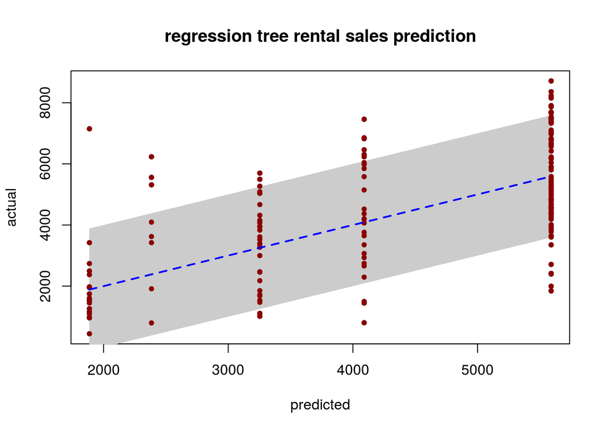

```r
plot_predict_actual(predicted, actual, 2000,
"regression tree rental sales prediction")
```

We actually found out that decision tree regression model didn’t perform very well on this particular dataset by plotting predicted values vs actual values.